# WPA #4 – Project management and advanced dataframe manipulation

## Readings

This assignment is based on the following readings:

- YaRrr: [9](https://bookdown.org/ndphillips/YaRrr/importingdata.html), [10](https://bookdown.org/ndphillips/YaRrr/advanceddataframe.html)
- Videos: [G](https://www.youtube.com/watch?v=jWjqLW-u3hc&feature=youtu.be)

## Assignment Goals

- Create a project with organised folders `data` and `R`.
- Read text files into R with `read.table()` and save text files from objects with `write.table()`
- Save multiple objects in a single `.RData` file using `save()`.
- Calculate aggregated summary statistics from dataframes with `aggregate()` and `dplyr`

# Examples

```r
library(yarrr) # Load yarrr for the pirates dataframe
library(dplyr) # Load dplyr for aggregation

# Start by creating a project with File -- New Project.
# put the project in the working directory you want on your computer.
# Then, create a folder called "data" in that working directory
#   by clicking "New Folder" in the File window in RStudio

# Print my current working directory (this is where you put your project)
getwd()

# Save the pirates dataframe to a tab--delimited txt file called pirates.txt in the data folder of my working directory

write.table(x = pirates,                 # Object to save to a table
            file = "data/pirates.txt",   # Location and name of the text file to save
            sep = "\t")                  # Separate columns with tabs

# For fun, read the pirates.txt file into R and save as a new dataframe object called pirates2

pirates2 <- read.table(file = "data/pirates.txt",   # Location of file
                       header = TRUE,               # There IS a header row
                       stringsAsFactors = FALSE)    # Do NOT convert strings to factors

# Grouped Aggregation

# Q: What is the mean age of pirates of different sexes?

# Using aggregate()
aggregate(formula = age ~ sex,   # DV is age, IV is sex
          data = pirates,        # Variables are in the pirates dataframe
          FUN = mean)            # Calculate means

# Using dplyr
pirates %>%           # Start with the pirates dataframe ..AND THEN...
  group_by(sex) %>%   # Group the data by sex ..AND THEN...
  summarise(          # Calculate summary statistics....
    N = n(),               # Number of cases in each group
    age_mean = mean(age)   # Mean age
  )

# Q: ONLY for male pirates, what is the median number of tattoos of pirates who do and do not wear headbands, and for different sexes?

# Using aggregate()
aggregate(formula = tattoos ~ headband + sex,   # DV is tattoos, IVs are headband and sex
          data = pirates,                       # Variables are in the pirates dataframe
          subset = sex == "male",               # Only male pirates
          FUN = median)                         # Calculate medians

# Using dplyr
pirates %>%                    # Start with the pirates dataframe ..AND THEN...
  filter(sex == "male") %>%       # Only include male pirates ..AND THEN..
  group_by(headband, sex) %>%  # Group the data by headband and sex ..AND THEN...
  summarise(                   # Calculate summary statistics....
    N = n(),                          # Number of cases in each group
    tattoos_median = median(tattoos)  # Median number of tattoos
  )


# Q: For each combination of sex and eyepatch, calculate the mean age, median height, mean weight, mean number of tattoos..
#      minimum sword.time, AND the percentage of pirates whose favorite pixar movie is "Monsters University".
#    Save the result as a dataframe called pirates_agg

pirates_agg <- pirates %>%
                group_by(sex, eyepatch) %>%
                summarise(
                  N = n(), # Number of cases in each group
                  age_mean = mean(age),
                  height_median = median(height),
                  weight_mean = mean(weight),
                  tattoos_mean = mean(tattoos),
                  sword_min = min(sword.time),
                  love_MU = mean(fav.pixar == "Monsters University")
                )

# Save pirates and pirates_agg objects in an .RData file called pirates.RData in the data folder of my working directory

save(pirates, pirates_agg,
     file = "data/pirates.RData")
```

## Why do we overestimate others’ willingness to pay?

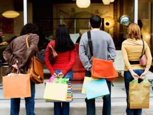

In this WPA, we will analyze data from Matthews et al. (2016): Why do we overestimate others’ willingness to pay? The purpose of this research was to test if our beliefs about other people’s affluence (i.e.; wealth) affect how much we think they will be willing to pay for items. You can find the full paper at http://journal.sjdm.org/15/15909/jdm15909.pdf.

In study 1 of their paper, participants indicated the proportion of other people taking part in the survey who have more than themselves (`havemore`), and then whether other people would be willing to pay more than them for each of 10 items.

The following table shows a table of the 10 items and proportion of participants who indicated that others would be more willing to pay for the product than themselves (Table 1 in Matthews et al., 2016).

#### Values reported in Table 1 of Matthews et al. (2016)

| Product Number | Product | Reported p(other > self) |
| --- | --- | --- |
| 1 | A freshly-squeezed glass of apple juice | .695 |
| 2 | A Parker ballpoint pen | .863 |
| 3 | A pair of Bose noise-cancelling headphones | .705 |
| 4 | A voucher giving dinner for two at Applebee’s | .853 |
| 5 | A 16 oz jar of Planters dry-roasted peanuts | .774 |
| 6 | A one-month movie pass | .800 |
| 7 | An Ikea desk lamp | .863 |
| 8 | A Casio digital watch | .900 |
| 9 | A large, ripe pineapple | .674 |
| 10 | A handmade wooden chess set | .732 |

*Table 1*: Proportion of participants who indicated that the “typical participant” would pay more than they would for each product in Study 1.

#### Variable Descriptions

Here are descriptions of the data variables (taken from the author’s dataset notes available at http://journal.sjdm.org/15/15909/Notes.txt)

- `id`: participant id code
- `gender`: participant gender. 1 = male, 2 = female
- `age`: participant age
- `income`: participant annual household income on categorical scale with 8 categorical options: Less than $15,000; $15,001–$25,000; $25,001–$35,000; $35,001–$50,000; $50,001–$75,000; $75,001–$100,000; $100,001–$150,000; greater than $150,000.
- `p1-p10`: whether the “typical” survey respondent would pay more (coded 1) or less (coded 0) than oneself, for each of the 10 products
- `task`: whether the participant had to judge the proportion of other people who “have more money than you do” (coded 1) or the proportion who “have less money than you do” (coded 0)
- `havemore`: participant’s response when task = 1
- `haveless`: participant’s response when task = 0
- `pcmore`: participant’s estimate of the proportion of people who have more than they do (calculated as 100-haveless when task=0)

### Creating a new project, loading and saving data

1. Open RStudio. Create a new project called `rcourse` (or anything else you want) in a new working directory on your computer. In the directory of the folder, create two folders: `R`, and `data` – you can do this either in RStudio (by clicking the “New Folder” icon in the Files window), or outside of RStudio in your computer browser. When you are finished, your file structure should look like this:

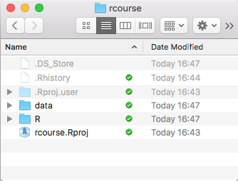

2. Open a new R script and save it as `wpa4.R` in the `R` folder you just created using the main RStudio menus “File – Save As”"
3. At the top of your script load the `dplyr` package using `library()`
4. Using `getwd()` print the current working directory of your project. This is the directory on your computer where your project is located.
5. Now it’s time to load the data. The data for this WPA are stored at http://journal.sjdm.org/15/15909/data1.csv. Load the data into R by using `read.table()` into a new object called `matthews` by running the following code. Once you have done this, kook at the first few rows of `matthews` using `head()`, and `str()` to make sure the data were loaded correctly into R.

```r
# Load the comma-separated data1.csv file into R as a new object called matthews

matthews <- read.table(file = "http://journal.sjdm.org/15/15909/data1.csv", # Link to the file
                       sep = ",",                             # File is comma-separated
                       header = TRUE,                         # There IS a header column
                       stringsAsFactors = FALSE)              # Do NOT convert strings to factors
```

6. Now that you’ve loaded the data into R, let’s save a local copy of the data as a text file called `matthews.txt` into your `data` folder. Using `write.table()`, save the data as a tab–delimited text file called `matthews.txt` in the data folder as follows:

```r
# Write the matthews data as a new, tab--delimited text file called matthews.txt in the data folder of
#   your working directory

write.table(x = matthews,                    # Save the object matthews
            file = "data/matthews.txt",      # Write the object to matthews.txt in the data folder
            sep = "\t")                      # Separate columns by tabs
```

### Review

7. What are the names of the data columns?
8. What was the mean age?
9. Currently the column `gender` is coded as 1 (male) and 2 (female). Let’s create a new *character* column called `gender_a` that codes the data as `"male"` and `"female"` (instead of 1 and 2). Do this by using the following template:

```r
matthews$gender_a <- NA   # Start with a column of NA values.
matthews$gender_a[matthews$gender == __] <- "__" # Change 1 to "male"
matthews$gender_a[matthews$gender == __] <- "__" # Change 2 to "female"
```

10. What percent of participants were male? (Hint: use the template: `mean(__$__ == "__")`)
11. Using either basic indexing, calculate the mean age for males only using the following templates

```r
mean(matthews$__[matthews$__ == "male"])
```

12. Using either basic indexing, calculate the mean age for females only using the following template

```r
mean(matthews$__[matthews$gender_a == "__"])
```

### Grouped Aggregation

13. Using `aggregate()` calculate the mean age of male and female participants separately using the following template. Do you get the same answers as before?

```r
# Calculate mean age for each sex using aggregate()
aggregate(formula = __ ~ __,
          FUN = __,
          data = __)
```

14. Now use `dplyr` to do the same calculations using the following template. Do you get the same answers as before?

```r
# Calculate mean age for each sex using dplyr
matthews %>%
  group_by(__) %>%
  summarise(
    N = n(),
    age_mean = mean(__)
  )
```

15. The variable `pcmore` reflects the question: “What percent of people taking part in this survey do you think earn more than you do?”. Using `aggregate()`, calculate the median value of this variable separately for each level of income. What does the result tell you?

### Merging two dataframes

16. I created a new table containing **fictional** demographic information about each participant. The data are stored in a **tab–delimited** text file (with a header row) at https://raw.githubusercontent.com/ndphillips/IntroductionR_Course/master/data/matthews_demographics.txt. Using `read.table()`, load the data into an object called `matthews_demo` into R using the following template:

```r
matthews_demo <- read.table(file = "___",          # File location
                            sep = "__",            # How are columns separted?
                            header = __,           # Is there a header row?
                            stringsAsFactors = __) # Should strings be converted to factors?
```

17. Using `merge()` add the demographic data to the `matthews` data using the following template:

```r
matthews <- merge(x = __,       # First dataframe
                  y = __,       # Second dataframe
                  by = "__")    # Column to match rows
```

18. Using `aggregate()`, calculate the mean value of `havemore` for each combination of gender and race using the following template. Is there a difference between men and women, or people of different races, in how often they think other people earn more money than them?

```r
aggregate(formula = __ ~ __ + __,
          FUN = __,
          data = __)
```

19. Now do the same calculations using `dplyr` using the following template. Do you get the same answer?

```r
matthews %>%
  group_by(__, __) %>%
  summarise(
    N = n(),
    havemore_mean = mean(__)
  )
```

# Checkpoint!!!

20. Create a new dataframe called `product` that only contain columns p1, p2, … p10 from `matthews` by running the following code. After you run the code, look at it with `head()` to see what it looks like.

```r
# Create product, a dataframe containing only columns p1, p2, ... p10
product <- matthews[,paste0("p", 1:10)]
```

21. The `colMeans()` function takes a dataframe as an argument, and returns a vector showing means across rows for each column of data. Using `colMeans()`, calculate the percentage of participants who indicated that the ‘typical’ participant would be willing to pay more than them for each item. Do your values match what the authors reported in Table 1?
22. The `rowMeans()` function is like `colMeans()`, but for calculating means across columns for every row of data. Using `rowMeans()` calculate for each participant, the percentage of the 10 items that the participant believed other people would spend more on. Save this data as a vector called `pall`.
23. Add the `pall` vector as a new column called `pall` to the `matthews` dataframe using basic assignment (`__$__ <- __`)
24. What was the mean value of `pall` across participants? This value is the answer to the question: “How often does the average participant think that someone else would pay more for an item than themselves?”
25. Calculate the mean `pall` value for male and female participants separately. Which gender tends to think that others would pay more for products than them?
26. Calculate the mean `pall` value of participants for each level of income. Do you find a consistent relationship between `pall` and income?
27. For each level of gender, calculate the summary statistics in the following table using the following template. Save the summary statistics to an object called `gender_agg`

| variable | description |
| --- | --- |
| n | Number of participants |
| age.mean | Mean age |
| age.sd | Standard deviation of age |
| income.mean | Mean income |
| pcmore.mean | Mean value of pcmore |
| pall.mean | Mean value of pall |

```r
gender_agg <- __ %>%
  group_by(__) %>%
  summarise(
    N = n(),
    age.mean = mean(age),
    age.sd = __,
    income.mean = __,
    pcmore.mean = __,
    pall.mean = __
  )
```

## Submit!

- Save and email your `wpa_4_LastFirst.R` file to me at nathaniel.phillips@unibas.ch.
- Go to https://goo.gl/forms/b9dcRH6Ud3pDagOr1 to confirm your assignment submission.